# Language Model Query Language and Retrieval Augmented Generation

By Chris Swart

```python
async def wikipedia(q):
    from lmql.http import fetch
    try:
        q = q.strip("\n '.").strip()
        pages = await fetch(f"https://en.wikipedia.org/w/api.php?format=json&action=query&prop=extracts&exintro&explaintext&redirects=1&titles={q}&origin=*", "query.pages")
        return list(pages.values())[0]["extract"][:500]
    except:
        return "No results"
```

```python
@lmql.query(model="gpt-4")
async def norse_origins():
    '''lmql
    "Q: From which countries did the Norse originate?\n"
    "Action: Let us search Wikipedia for the term '[TERM]\n" where STOPS_AT(TERM, "'")
    wiki_result = await wikipedia(TERM)
    "Result: {wiki_result}\n"
    "Final Answer:[ANSWER]"
    '''

result = await norse_origins()
```

```python
pretty_html(result)
```

**Q: From which countries did the Norse originate?**  
Action: Let us search Wikipedia for the term ' Norse'  
Result: Norse is a demonym for Norsemen, a Medieval North Germanic ethnolinguistic group ancestral to modern Scandinavians, defined as speakers of Old Norse from about the 9th to the 13th centuries.  
Norse may also refer to:  
Final Answer: The Norse originated from the North Germanic region, which is modern Scandinavia.

```python
@lmql.query()
async def rhetoric():
    '''lmql
    "Q: How was rhetoric taught in Ancient Greece?\n"
    "Action: Let us search Wikipedia for the term '[TERM]\n" where STOPS_AT(TERM, "'")
    wiki_result = await wikipedia(TERM)
    "Result: {wiki_result}\n"
    "Final Answer:[ANSWER]"
    '''
result = await rhetoric()
```

```python
pretty_html(result)
```

**Q: How was rhetoric taught in Ancient Greece?**  
Action: Let us search Wikipedia for the term 'rhetoric'  
Result: Rhetoric () is the art of persuasion. It is one of the three ancient arts of discourse (trivium) along with grammar and logic/dialectic. As an academic discipline within the humanities, rhetoric aims to study the techniques that speakers or writers use to inform, persuade, and motivate their audiences. Rhetoric also provides heuristics for understanding, discovering, and developing arguments for particular situations.  
Aristotle defined rhetoric as "the faculty of observing in any given case the  
Final Answer: According to Wikipedia, rhetoric was taught as one of the three ancient arts of discourse (along with grammar and logic/dialectic) and aimed to study the techniques of persuasion. It was also seen as a way to understand and develop arguments for specific situations. Aristotle defined rhetoric as "the faculty of observing in any given case the available means of persuasion."

```python
@lmql.query(temperature=1.3)
async def rhetoric_v2():
    '''lmql
    "Q: How was rhetoric taught in Ancient Greece?\n"
    for i in range(4):
        "Action: Let us search Wikipedia for the wikipedia keyword '[TERM]\n" where STOPS_AT(TERM, "'")
        print(TERM)
        wiki_result = await wikipedia(TERM)
        "Result for '{TERM}: {wiki_result}\n"
    "If some of the results are relevant try to answer the question otherwise say NOT ENOUGH INFORMATION and explain why.\n"
    "Final Answer:[ANSWER]"
    '''

result = await rhetoric_v2()
```

```
rhetoric in Ancient Greece'
rhetoric education in Ancient Greece'
Ancient Greek education'
Ancient Greek schooling'
```

```python
pretty_html(result)
```

**Q: How was rhetoric taught in Ancient Greece?**  
Action: Let us search Wikipedia for the wikipedia keyword 'rhetoric in Ancient Greece'  
Result for 'rhetoric in Ancient Greece': No results  
Action: Let us search Wikipedia for the wikipedia keyword 'rhetoric education in Ancient Greece'  
Result for 'rhetoric education in Ancient Greece': No results  
Action: Let us search Wikipedia for the wikipedia keyword 'Ancient Greek education'  
Result for 'Ancient Greek education': No results  
Action: Let us search Wikipedia for the wikipedia keyword 'Ancient Greek schooling'  
Result for 'Ancient Greek schooling': No results  
If some of the results are relevant try to answer the question otherwise say NOT ENOUGH INFORMATION and explain why.  
Final Answer: NOT ENOUGH INFORMATION. Although rhetoric and education were important components of Ancient Greece's culture and society, it seems like there is limited information about specific ways in which rhetoric was taught in Ancient Greece. More research on primary sources and other academic articles may yield more information on the subject.

```python
@lmql.query
def items_list(n: int):
    '''lmql
    for i in range(n):
        "- '[ITEM]" where STOPS_AT(ITEM, "'")
    '''

@lmql.query
async def rhetoric_v3():
    """
    "Q: How was rethoric taught in Ancient Greece?\n"
    "Relevant wikipedia search search keywords:\n[TERMS: items_list(3)]\n"
    keywords = [e.split("'")[1] for e in TERMS.split("-")[1:]]
    for kw in keywords:
        wiki_result = await wikipedia(kw)
        "Result for '{kw}': {wiki_result}\n"
    "Final Answer:[ANSWER]"
     """

result = await rhetoric_v3()
```

```python
pretty_html(result)
```

**Q: How was rethoric taught in Ancient Greece?**  
Relevant wikipedia search search keywords:  
- 'rhetoric'- 'Ancient Greece'- 'education'  
Result for 'rhetoric': Rhetoric () is the art of persuasion. It is one of the three ancient arts of discourse (trivium) along with grammar and logic/dialectic. As an academic discipline within the humanities, rhetoric aims to study the techniques that speakers or writers use to inform, persuade, and motivate their audiences. Rhetoric also provides heuristics for understanding, discovering, and developing arguments for particular situations.  
Aristotle defined rhetoric as "the faculty of observing in any given case the  
Result for 'Ancient Greece': Ancient Greece (Ancient Greek: Ἑλλάς, romanized: Hellás) was a northeastern Mediterranean civilization, existing from the Greek Dark Ages of the 12th–9th centuries BC to the end of classical antiquity (c. 600 AD), that comprised a loose collection of culturally and linguistically related city-states and other territories. Prior to the Roman period, most of these regions were officially unified once under the Kingdom of Macedon from 338 to 323 BC. In Western history, the era of classical antiquit  
Result for 'education': Education is the transmission of knowledge, skills, and character traits and manifests in various forms. Formal education occurs within a structured institutional framework, such as public schools, following a curriculum. Non-formal education also follows a structured approach but occurs outside the formal schooling system, while informal education entails unstructured learning through daily experiences. Formal and non-formal education are categorized into levels, including early childhood educa  
Final Answer: Rhetoric was taught in Ancient Greece as one of the three ancient arts of discourse, along with grammar and logic/dialectic. It was considered an important academic discipline within the humanities and aimed to study the techniques of persuasion and argumentation. The philosopher Aristotle defined rhetoric as the "faculty of observing in any given case the available means of persuasion." Education in Ancient Greece included both formal and non-formal methods, with a focus on developing knowledge, skills, and character traits.

```python
print(get_stats())
```

```
OpenAI API Stats: 9 requests, 0 errors, 1489 tokens, 1.0 average batch size, reserved capacity 0/32000
```

# Evaluating RAG

### Context Recall

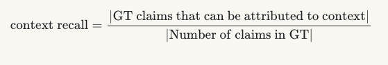

Prompt used

Given a context, and an answer, analyze each sentence in the answer and classify if the sentence can be attributed to the given context or not. Use only 'Yes' (1) or 'No' (0) as a binary classification. Output json with reason.

### Factual Correctness

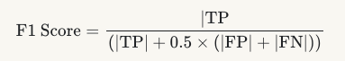

Where:

**TP (True Positives):** Statements in both Ground Truth and Generated Answer

**FP (False Positives):** Statements in Generated Answer but not in Ground Truth

**FN (False Negatives):** Statements in Ground Truth but not in Generated Answer

```python
from IPython.display import HTML

HTML(html_content)
```

Factual Correctness

Ground Truth

Generated Answer

FN

TP

FP

Faithfulness

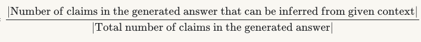

```python
from datasets import load_dataset
dataset = load_dataset("explodinggradients/amnesty_qa","english_v3")
```

```
Repo card metadata block was not found. Setting CardData to empty.
Generating eval split: 20 examples [00:00, 1412.13 examples/s]
```

```python
@lmql.query(model="gpt-4")
async def infer_response(user_input: str):
    '''lmql
    "Q: {user_input}\n"
    for i in range(4):
        "Action: Let's search Wikipedia for the wikipedia keyword '[TERM]\n" where STOPS_AT(TERM, "'")
        result = await wikipedia(TERM)
        "Result: {result}\n"
    "Final Answer:[ANSWER]"
    '''

inferred_result = await infer_response(user_input='When did the government of Qatar start repealing restrictions on migrant workers?')
```

```python
from typing import List, Dict, Any
async def modify_dataset(dataset: EvaluationDataset) -> List[Dict[str, Any]]:
    modified_samples = []

    for sample in dataset:
        inferred_result = await infer_response(sample.user_input)
        print(inferred_result)

        modified_sample = {
            "user_input": sample.user_input,
            "retrieved_contexts": extract_results(inferred_result.prompt),
            "reference_contexts": sample.reference_contexts,
            "response": inferred_result.variables["ANSWER"],
            "multi_responses": sample.multi_responses,
            "reference": sample.reference,
            "rubric": sample.rubric
        }
        modified_samples.append(modified_sample)

    return modified_samples
```

```python
from ragas.llms import LangchainLLMWrapper
from langchain_openai import ChatOpenAI
evaluator_llm = LangchainLLMWrapper(ChatOpenAI(model="gpt-4"))
```

```python
metrics = [LLMContextRecall(), FactualCorrectness(), Faithfulness()]
results = evaluate(dataset=new_eval_dataset, metrics=metrics, llm=evaluator_llm,)
```

[output not shown]

```python
results
```

```
{'context_recall': 0.0667, 'factual_correctness': 0.1900, 'faithfulness': 0.0909}
```

### Context Recall

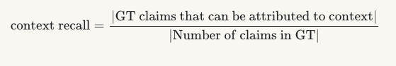

Prompt used

Given a context, and an answer, analyze each sentence in the answer and classify if the sentence can be attributed to the given context or not. Use only 'Yes' (1) or 'No' (0) as a binary classification. Output json with reason.

### Factual Correctness

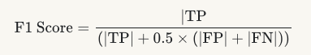

Where:

**TP (True Positives):** Statements in both Ground Truth and Generated Answer

**FP (False Positives):** Statements in Generated Answer but not in Ground Truth

**FN (False Negatives):** Statements in Ground Truth but not in Generated Answer

```python
from IPython.display import HTML

HTML(html_content)
```

Factual Correctness

Ground Truth

Generated Answer

FN

TP

FP

Faithfulness

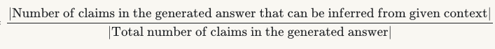

### First example

```python
i = 0
print(f"""
QUESTION:
{new_eval_dataset[i].user_input}

EXPECTED ANSWER:
{new_eval_dataset[i].reference}
""")
```

```
QUESTION:
What are the global implications of the USA Supreme Court ruling on abortion?

EXPECTED ANSWER:
The global implications of the USA Supreme Court ruling on abortion are significant. The ruling has led to limited or no access to abortion for one in three women and girls of reproductive age in states where abortion access is restricted. These states also have weaker maternal health support, highe…
```

```python
i = 0

print(f"""
GENERATED ANSWER:
{new_eval_dataset[i].response}

RETRIEVED CONTEXTS
{[e for e in new_eval_dataset[i].retrieved_contexts if e != 'No results']}""")
```

```
GENERATED ANSWER:
 The information available does not provide specific details on the global implications of the USA Supreme Court ruling on abortion. However, the Roe v. Wade decision in 1973 by the U.S. Supreme Court generally protected a right to have an abortion, sparking an ongoing debate in the United States ab…

RETRIEVED CONTEXTS
['Roe v. Wade, 410 U.S. 113 (1973), was a landmark decision of the U.S. Supreme Court in which the Court ruled that the Constitution of the United States generally protected a right to have an abortion. The decision struck down many abortion laws, and caused an ongoing abortion debate in the United …
```

### Second example

```python
i = 6
print(f"""
QUESTION:
{new_eval_dataset[i].user_input}

EXPECTED ANSWER:
{new_eval_dataset[i].reference}
""")
```

```
QUESTION:
Which right guarantees access to comprehensive information about past human rights violations, including the identities of the perpetrators and the fate of the victims, as well as the circumstances surrounding the violations?

EXPECTED ANSWER:
The right that guarantees access to comprehensive information about past human rights violations, including the identities of the perpetrators and the fate of the victims, as well as the circumstances surrounding the violations, is the right to know the truth.
```

```python
i = 6

print(f"""
GENERATED ANSWER:
{new_eval_dataset[i].response}

RETRIEVED CONTEXTS
{[e for e in new_eval_dataset[i].retrieved_contexts if e != 'No results']}""")
```

```
GENERATED ANSWER:
 The right that guarantees access to comprehensive information about past human rights violations, including the identities of the perpetrators and the fate of the victims, as well as the circumstances surrounding the violations, is known as the "Right to Truth". This right is especially relevant to…

RETRIEVED CONTEXTS
["Right to truth is the right, in the case of grave violations of human rights, for the victims and their families or societies to have access to the truth of what happened. The right to truth is closely related to, but distinct from, the state obligation to investigate and prosecute serious state v…
```

### Third example

```python
i = 11

print(f"""
QUESTION:
{new_eval_dataset[i].user_input}

EXPECTED ANSWER:
{new_eval_dataset[i].reference}""")
```

```
QUESTION:
What conditions designate wetlands as Ramsar sites?

EXPECTED ANSWER:
The conditions that designate wetlands as Ramsar sites are when they fulfill the criteria for identifying wetlands of international importance, as established under the Convention on Wetlands.
```

```python
i = 11
print(f"""GENERATED ANSWER:
{new_eval_dataset[i].response}

RETRIEVED CONTEXTS
{[e for e in new_eval_dataset[i].retrieved_contexts if e != 'No results']}""")
```

```
GENERATED ANSWER:
 A Ramsar site is a wetland site designated to be of international importance under the Ramsar Convention. This convention is an international environmental treaty signed in 1971 in Ramsar, Iran, under the auspices of UNESCO. It provides for national action and international cooperation regarding th…

RETRIEVED CONTEXTS
['A Ramsar site is a wetland site designated to be of international importance under the Ramsar Convention, also known as "The Convention on Wetlands",  an international environmental treaty signed on 2 February 1971 in Ramsar, Iran, under the auspices of UNESCO. It came into force on 21 December 19…
```

## Connect with me on LinkedIn

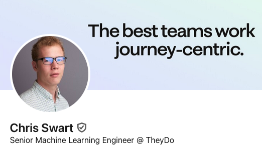